# Project 2

# 1 Linear models

In this project we tried to evaluate how average the value of the houses occupied owners, depends on various factors.

## 1.1 Breif EDA

Perform exploratory data analysis, look at the data structure and outliers.

```
## 'data.frame':    506 obs. of  14 variables:
##  $ crim   : num  0.00632 0.02731 0.02729 0.03237 0.06905 ...
##  $ zn     : num  18 0 0 0 0 0 12.5 12.5 12.5 12.5 ...
##  $ indus  : num  2.31 7.07 7.07 2.18 2.18 2.18 7.87 7.87 7.87 7.87 ...
##  $ chas   : int  0 0 0 0 0 0 0 0 0 0 ...
##  $ nox    : num  0.538 0.469 0.469 0.458 0.458 0.458 0.524 0.524 0.524 0.524 ...
##  $ rm     : num  6.58 6.42 7.18 7 7.15 ...
##  $ age    : num  65.2 78.9 61.1 45.8 54.2 58.7 66.6 96.1 100 85.9 ...
##  $ dis    : num  4.09 4.97 4.97 6.06 6.06 ...
##  $ rad    : int  1 2 2 3 3 3 5 5 5 5 ...
##  $ tax    : num  296 242 242 222 222 222 311 311 311 311 ...
##  $ ptratio: num  15.3 17.8 17.8 18.7 18.7 18.7 15.2 15.2 15.2 15.2 ...
##  $ black  : num  397 397 393 395 397 ...
##  $ lstat  : num  4.98 9.14 4.03 2.94 5.33 ...
##  $ medv   : num  24 21.6 34.7 33.4 36.2 28.7 22.9 27.1 16.5 18.9 ...
```

There is no NA values in this dataset.

We paid attention to two variables of type int, perhaps we should return them as factors.

We looked at the graph of dependence of medv on these variables and noted that they are discrete, so they can be turned into factors.

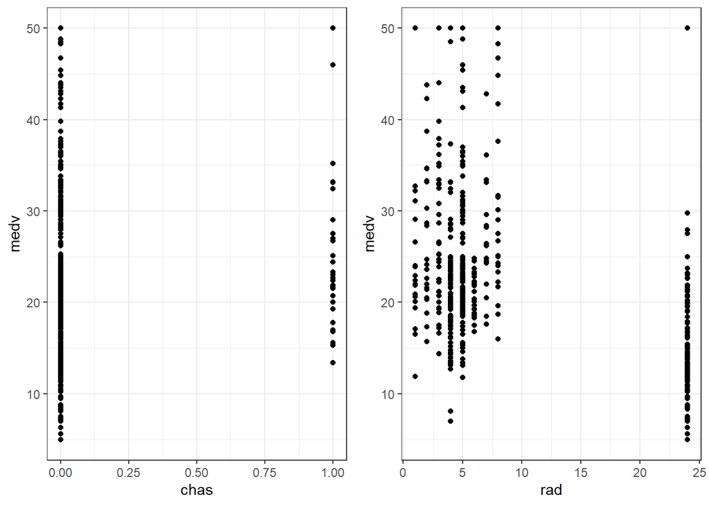

### 1.1.1 Outliers visualisation.

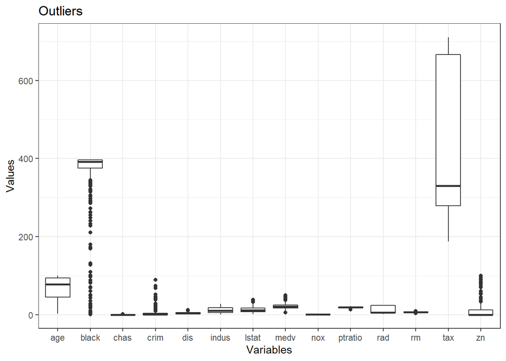

### 1.1.2 Data standartisation

We pointed that variables scales are really different, so we applied data standardization.

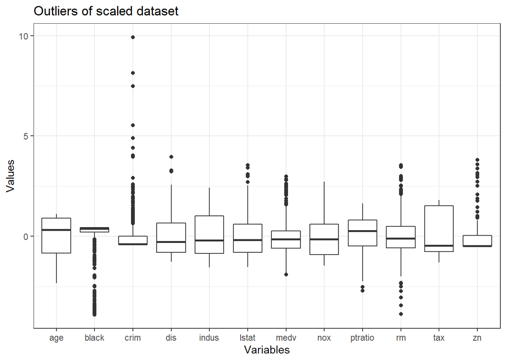

## 1.2 Linear model

Build a linear model

```
##
## Call:
## lm(formula = medv ~ ., data = df_scale)
##
## Residuals:
##      Min       1Q   Median       3Q      Max
## -1.64204 -0.29743 -0.04963  0.18289  2.82100
##
## Coefficients:
##              Estimate Std. Error t value Pr(>|t|)
## (Intercept) -0.458954   0.125554  -3.655 0.000285 ***
## crim        -0.101774   0.030569  -3.329 0.000937 ***
## zn           0.139209   0.035880   3.880 0.000119 ***
## indus        0.017723   0.047476   0.373 0.709081
## nox         -0.221410   0.049092  -4.510 8.13e-06 ***
## rm           0.280027   0.032177   8.703  < 2e-16 ***
## age          0.001411   0.040482   0.035 0.972210
## dis         -0.355919   0.046228  -7.699 7.75e-14 ***
## tax         -0.160310   0.071371  -2.246 0.025144 *
## ptratio     -0.228902   0.034009  -6.731 4.78e-11 ***
## black        0.093247   0.026411   3.531 0.000454 ***
## lstat       -0.410916   0.039319 -10.451  < 2e-16 ***
## chas1        0.274452   0.093854   2.924 0.003614 **
## rad2         0.161888   0.160649   1.008 0.314095
## rad3         0.508992   0.145187   3.506 0.000498 ***
## rad4         0.280114   0.129102   2.170 0.030514 *
## rad5         0.317327   0.131303   2.417 0.016028 *
## rad6         0.128936   0.159182   0.810 0.418342
## rad7         0.530492   0.170836   3.105 0.002012 **
## rad8         0.526235   0.162188   3.245 0.001257 **
## rad24        0.811307   0.194483   4.172 3.58e-05 ***
## ---
## Signif. codes:  0 '***' 0.001 '**' 0.01 '*' 0.05 '.' 0.1 ' ' 1
##
## Residual standard error: 0.5103 on 485 degrees of freedom
## Multiple R-squared:  0.7499, Adjusted R-squared:  0.7396
## F-statistic:  72.7 on 20 and 485 DF,  p-value: < 2.2e-16
```

## 1.3 Model Diagnostics

We checked the applicability conditions of our model and found some problems.

### 1.3.1 Checking the linearity of the relationship

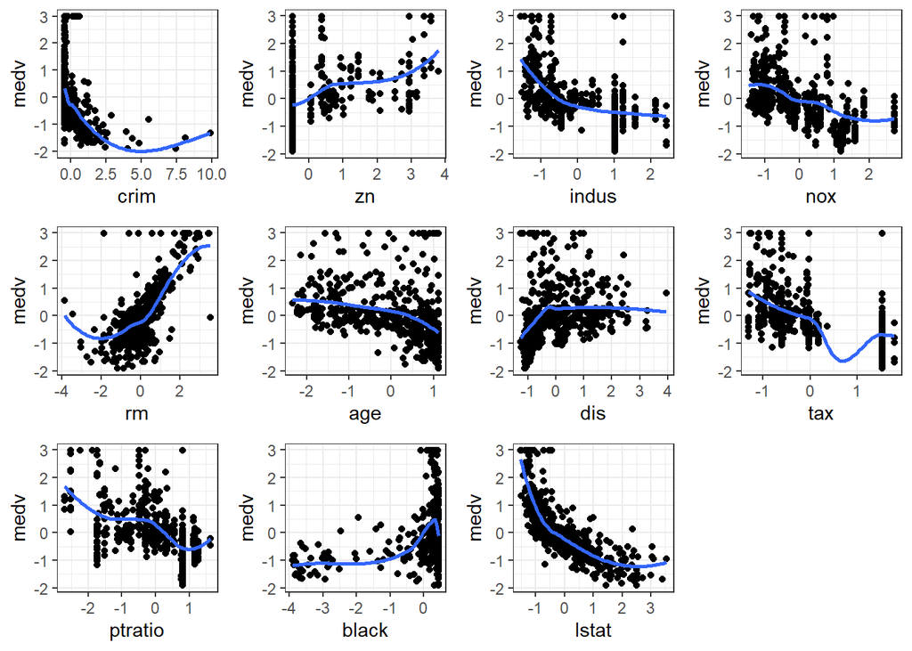

The graph shows the nonlinearity of the relationship (for example lstat, crim, dis variables).

### 1.3.2 Influential observations and residues distribution checking

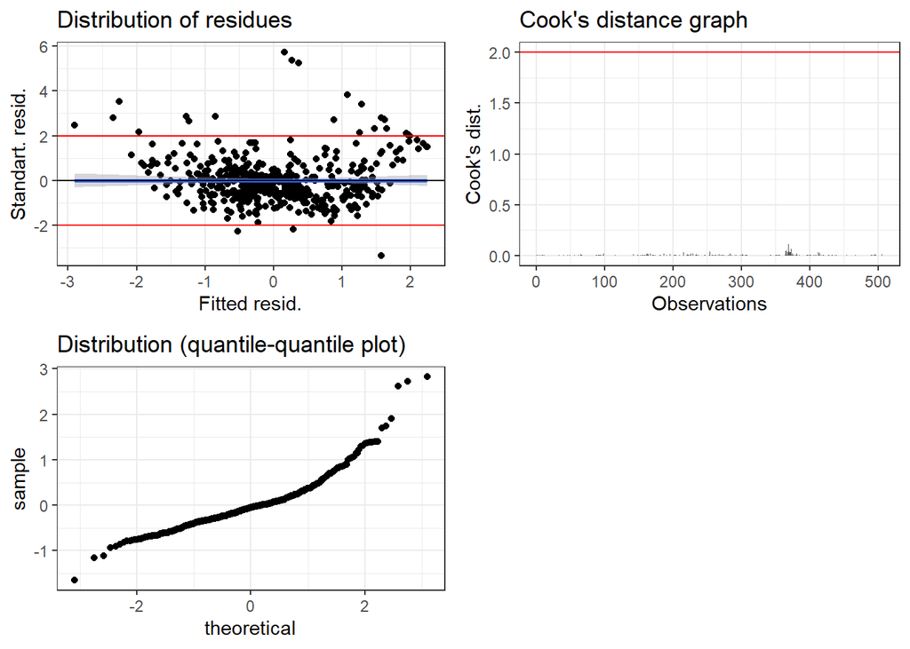

The first graph shows that the residues are unevenly distributed. We can see dispersion heteroskedasticity. Also here we can notice nonlinearity of relationship as not all observations are in the +/- 2 standard deviation zone. In addition, the residuals are unevenly distributed, we conclude that the variables are not independent.

Cook’s distance graph shows that there is no influential observations.

Distribution graf shows that residual’s distribution differs from normal.

### 1.3.3 Multicollinearity check

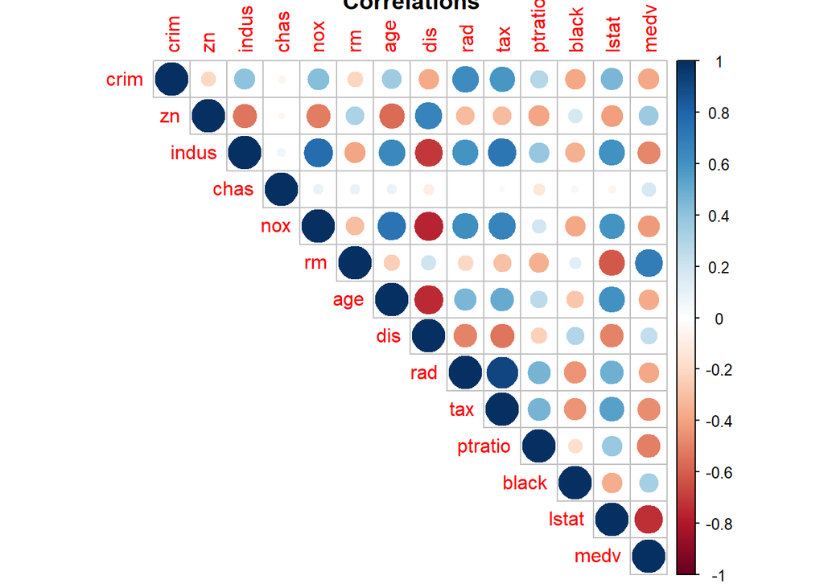

|  | GVIF | Df |
| --- | --- | --- |
| crim | 1.811867 | 1 |
| zn | 2.496184 | 1 |
| indus | 4.370471 | 1 |
| nox | 4.672906 | 1 |
| rm | 2.007593 | 1 |
| age | 3.177556 | 1 |
| dis | 4.143583 | 1 |
| tax | 9.876853 | 1 |
| ptratio | 2.242683 | 1 |
| black | 1.352515 | 1 |
| lstat | 2.997620 | 1 |
| chas | 1.101843 | 1 |
| rad | 18.783126 | 8 |

As though variance inflation factor of some variables is higher then 2, we conclude that there is multicollinearity in our data. The same thing we can see in correlations plot.

### 1.3.4 predicting houses costs depending on the variable with the highest coefficient

From the model summary we conclude that rad variable (index of accessibility to radial highways) has the highest estimate. Sinse rad is the factor variable in our model prediction of house costs (depending on 24 level of rad) is not informative. So we constructed graf of a value predictions of a variable that has the next largest modulo coefficient (lstat)

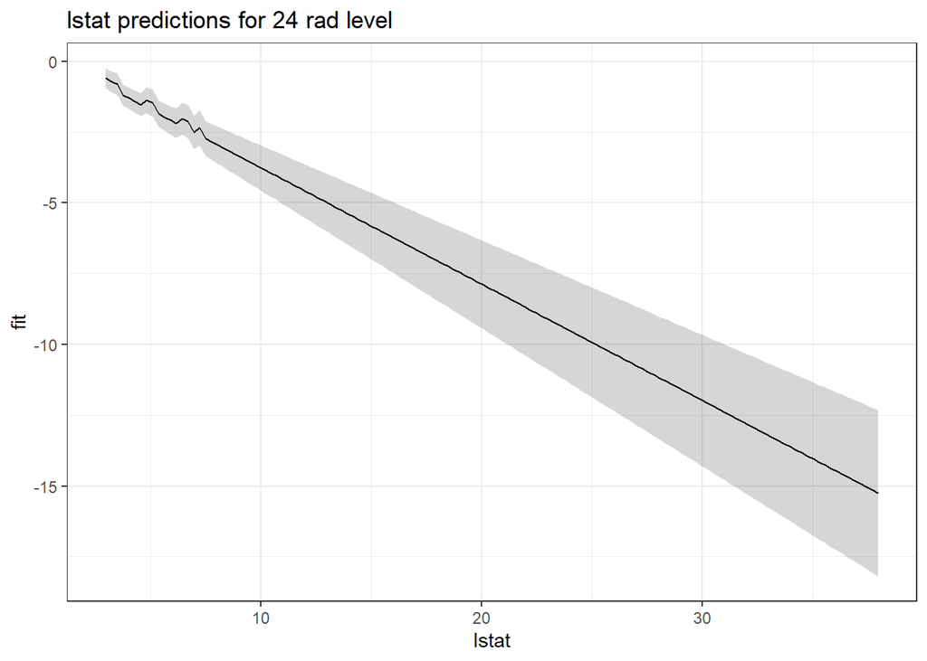

Since the applicability conditions are not met in the model, this graph is not informative.

## 1.4 Conclusions of the model quality

During the analysis we’ve showed that practically all the conditions of applicability are not performed. Unfortunately, such a model cannot be subjective.

So we decided to try to improve quality of this model.

# 2 Improving model quality

Since we want to understand what the cost of houses depends on, we need to build a valid linear model so that it is possible to predict the cost depending on various conditions.

We remove predictors from the model one by one depending on the vif value (first the largest one, until all vifs in the model are less than 2). Now the model is following

```
##
## Call:
## lm(formula = medv ~ crim + rm + age + ptratio + black + chas,
##     data = df_scale)
##
## Residuals:
##     Min      1Q  Median      3Q     Max
## -2.1005 -0.3188 -0.0811  0.1863  4.3171
##
## Coefficients:
##             Estimate Std. Error t value Pr(>|t|)
## (Intercept) -0.02655    0.02797  -0.949 0.342916
## crim        -0.10137    0.03115  -3.254 0.001213 **
## rm           0.53869    0.02943  18.303  < 2e-16 ***
## age         -0.12292    0.03021  -4.069 5.50e-05 ***
## ptratio     -0.21653    0.03013  -7.186 2.44e-12 ***
## black        0.14865    0.02967   5.010 7.56e-07 ***
## chas1        0.38390    0.10838   3.542 0.000434 ***
## ---
## Signif. codes:  0 '***' 0.001 '**' 0.01 '*' 0.05 '.' 0.1 ' ' 1
##
## Residual standard error: 0.6062 on 499 degrees of freedom
## Multiple R-squared:  0.6369, Adjusted R-squared:  0.6325
## F-statistic: 145.9 on 6 and 499 DF,  p-value: < 2.2e-16
```

The model is optimized. Now it is necessary to re-diagnose it.

[figure not shown]

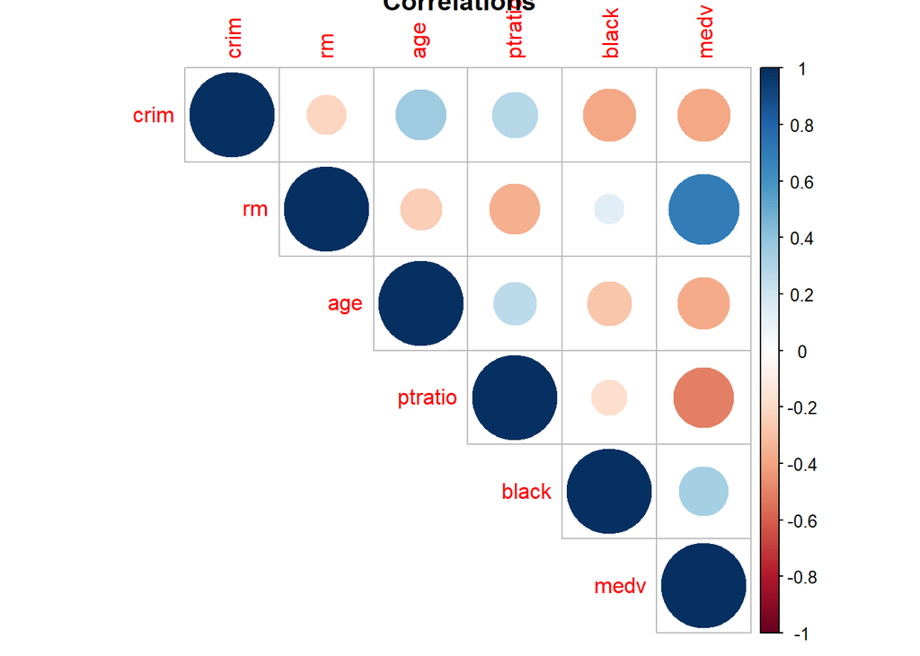

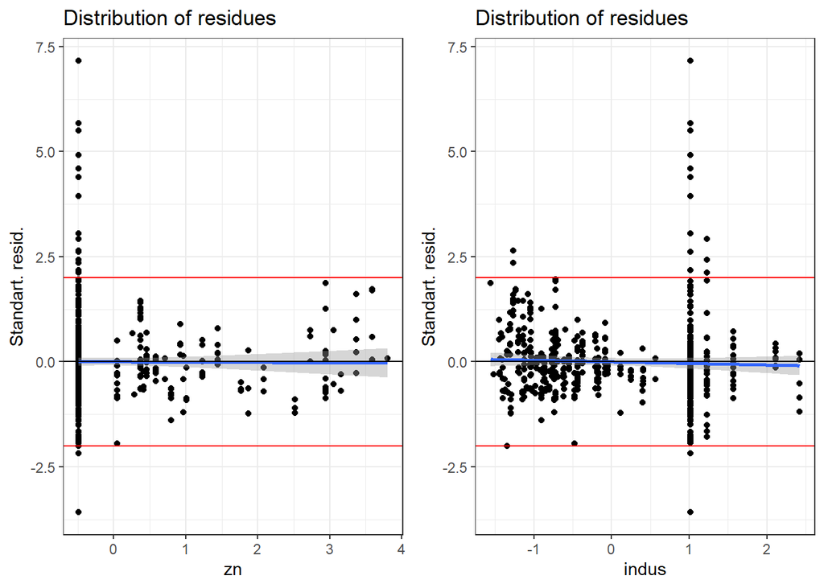

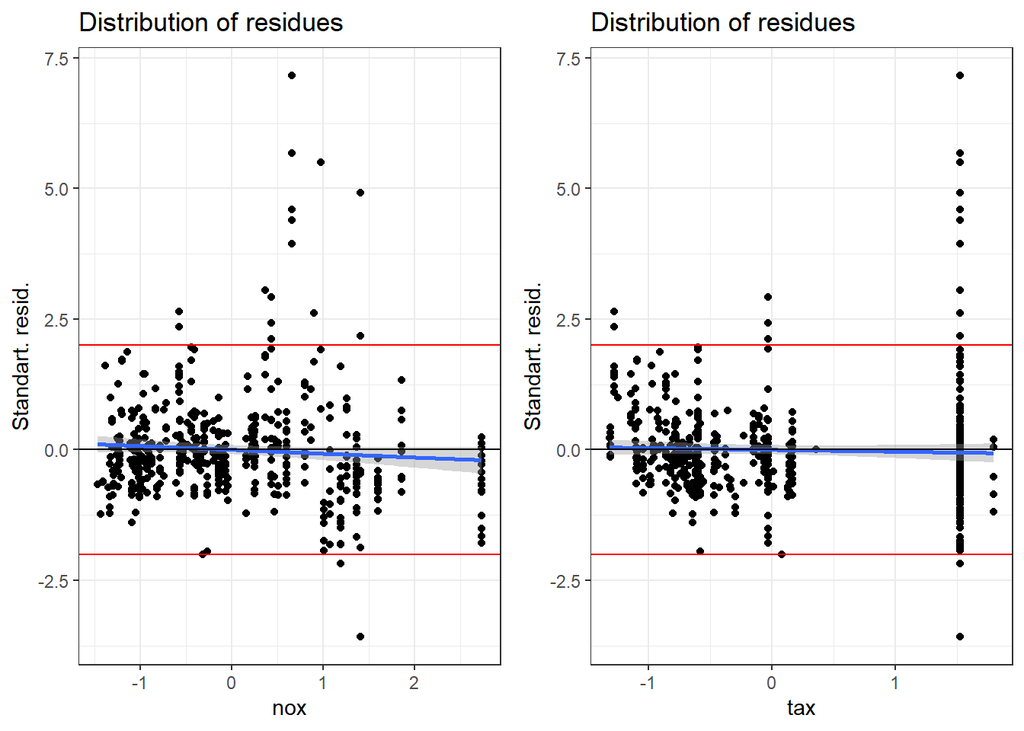

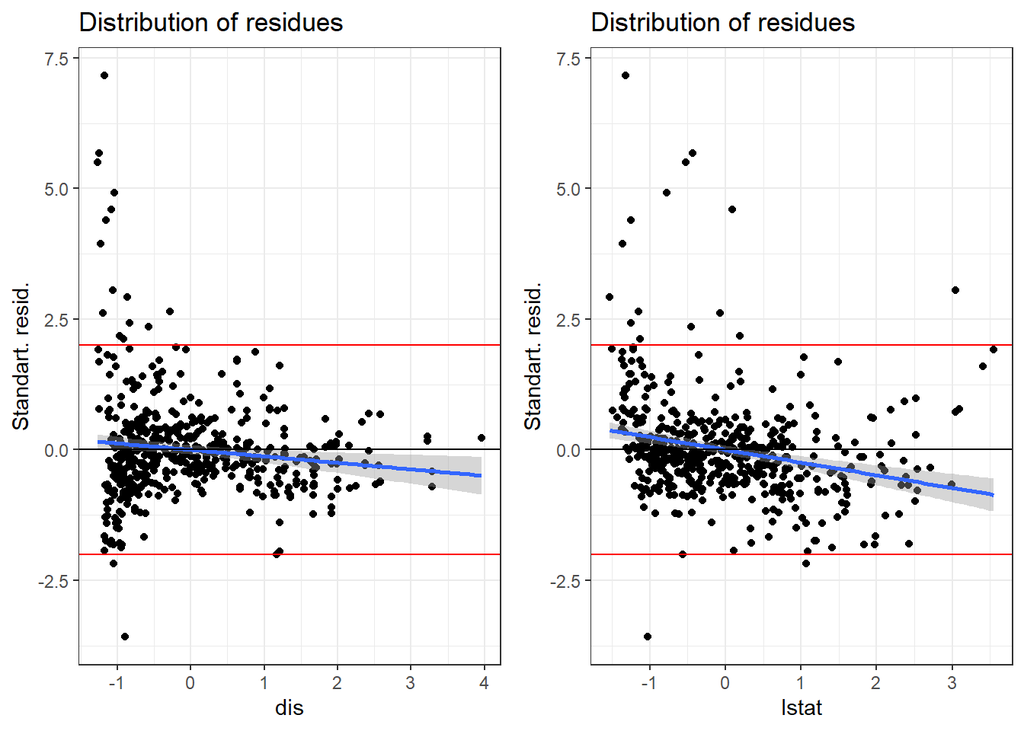

We noticed that the residuals from lstat and dis are the most explicit. We put them back in the model.

```
##
## Call:
## lm(formula = medv ~ crim + rm + age + ptratio + black + chas +
##     lstat + dis, data = df_scale)
##
## Residuals:
##      Min       1Q   Median       3Q      Max
## -1.98543 -0.30674 -0.08324  0.16784  3.13714
##
## Coefficients:
##             Estimate Std. Error t value Pr(>|t|)
## (Intercept) -0.02084    0.02496  -0.835 0.404315
## crim        -0.05782    0.02878  -2.009 0.045049 *
## rm           0.35038    0.03206  10.930  < 2e-16 ***
## age         -0.08197    0.04019  -2.040 0.041918 *
## ptratio     -0.20286    0.02693  -7.532 2.37e-13 ***
## black        0.10397    0.02711   3.836 0.000141 ***
## chas1        0.30124    0.09710   3.102 0.002030 **
## lstat       -0.42025    0.04069 -10.328  < 2e-16 ***
## dis         -0.18398    0.03715  -4.952 1.01e-06 ***
## ---
## Signif. codes:  0 '***' 0.001 '**' 0.01 '*' 0.05 '.' 0.1 ' ' 1
##
## Residual standard error: 0.5409 on 497 degrees of freedom
## Multiple R-squared:  0.7121, Adjusted R-squared:  0.7075
## F-statistic: 153.7 on 8 and 497 DF,  p-value: < 2.2e-16
```

Now model is: medv = -0.0208369 + crim * (-0.0578184) + rm * (0.3503836) + age* (-0.0819693) + ptratio* (-0.2028634) + black * (0.1039709) + chas * (0.3012416) + lstat* (-0.420248) + dis* (-0.183983)

We diagnosed it again.

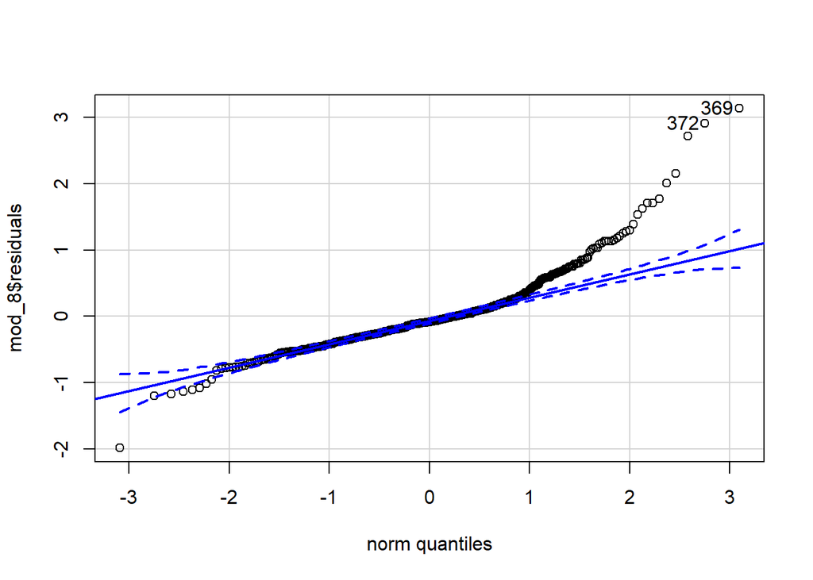

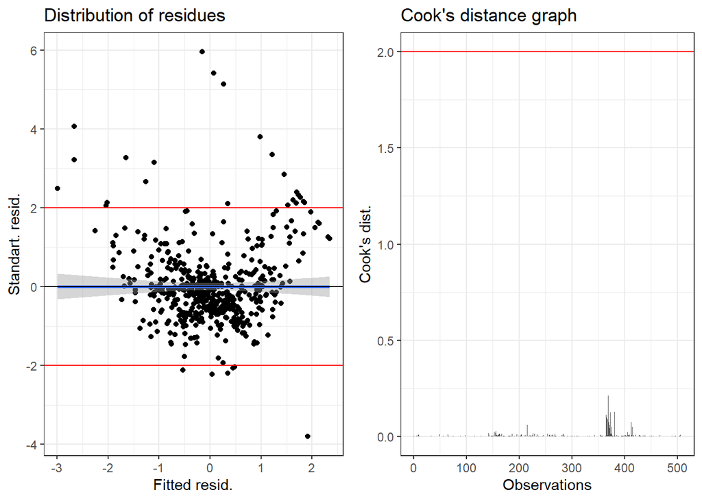

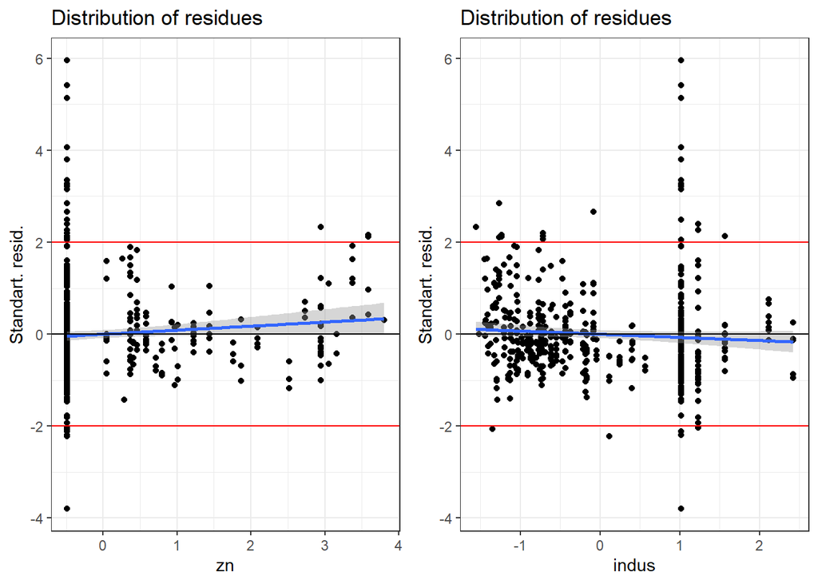

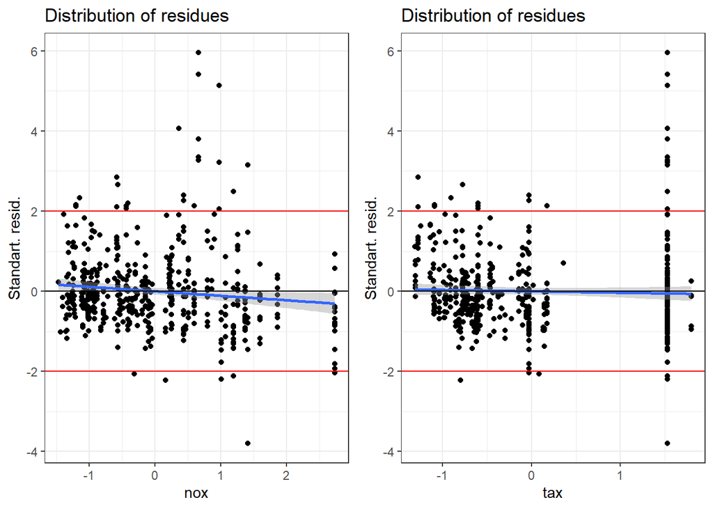

# 3 Final model

As we remember from EDA lstat var is not linear so we can use squared lstat for better fit.

That is our final model:

```
##
## Call:
## lm(formula = medv ~ . - age - indus + I(lstat^2) - rad, data = df_scale)
##
## Residuals:
##      Min       1Q   Median       3Q      Max
## -1.93951 -0.28445 -0.03426  0.19571  2.80118
##
## Coefficients:
##             Estimate Std. Error t value Pr(>|t|)
## (Intercept) -0.20845    0.02841  -7.337 9.00e-13 ***
## crim        -0.10227    0.02751  -3.718 0.000224 ***
## zn           0.04223    0.03227   1.309 0.191262
## nox         -0.15909    0.04148  -3.835 0.000142 ***
## rm           0.26998    0.02866   9.421  < 2e-16 ***
## dis         -0.29698    0.03941  -7.535 2.35e-13 ***
## tax          0.02986    0.03649   0.818 0.413510
## ptratio     -0.16522    0.02803  -5.895 6.93e-09 ***
## black        0.07283    0.02456   2.965 0.003169 **
## lstat       -0.65402    0.04159 -15.726  < 2e-16 ***
## chas1        0.31264    0.08583   3.642 0.000299 ***
## I(lstat^2)   0.18719    0.01809  10.349  < 2e-16 ***
## ---
## Signif. codes:  0 '***' 0.001 '**' 0.01 '*' 0.05 '.' 0.1 ' ' 1
##
## Residual standard error: 0.4773 on 494 degrees of freedom
## Multiple R-squared:  0.7772, Adjusted R-squared:  0.7722
## F-statistic: 156.6 on 11 and 494 DF,  p-value: < 2.2e-16
```

R-squared and adjusted R-squared are bigger then in previous model.

But still we need to diagnoste it.

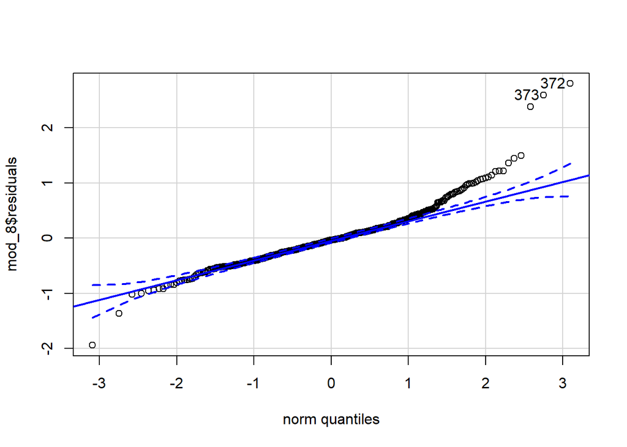

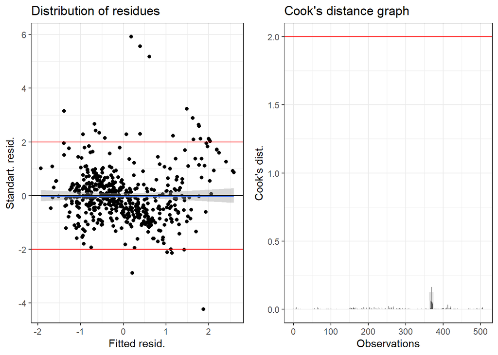

Now distribution of residuals looks better. And quantile-quantile plot too.

Nice.

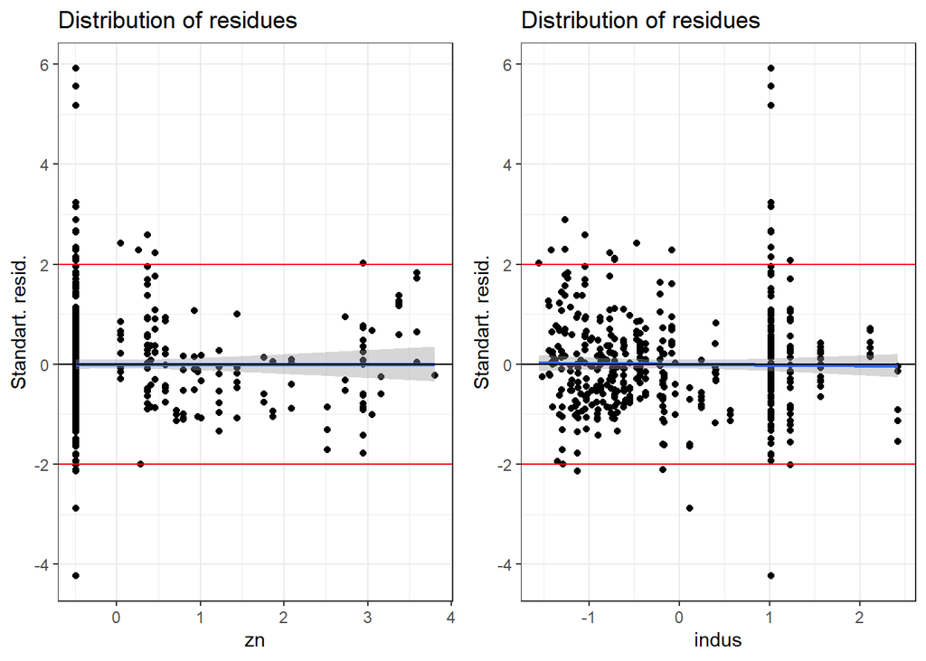

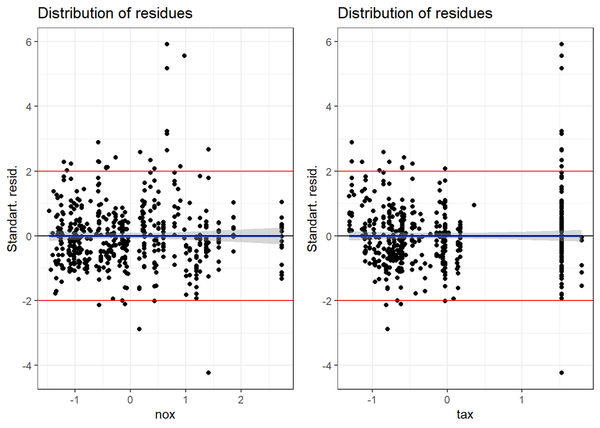

# 4 Conclusion

We can conclude that there is no reason trying to optimize this model again.

Since there is no simple observable linear relationship in the data, we cannot build an optimal adequate and good model.

Despite the fact that we have selected a good model compared to the previous ones, we consider it is dangerous to make predictions of the houses costs based on it because of the possibility of obtaining incorrect results.

That is why we did not built a graf of the predictions of the medv value.

But other methods still can be used to parse this dataset, such as the principal component analysis for example.